# dge1

Jordan Lee

3/5/2020

# Info

Input DESeq2 requires raw counts (not normalized, not scaled, and optional if been batch correctd). If input to DESeq is not batch corrected then we incorporate this into our modeling in DESeq2. Additionally, DESeq2 can estimate size factors (correct for differences between samples unrelated to experiment)…more on size factors

- **Normalizing for sequencing depth and RNA composition** = sample specific **size factors are estimated by median ratio of gene counts relative to geometric mean per gene** thus allows for between sample comparisons.
- to do this it creates a pseudo-reference sample per gene (using all samples) –> sample-gene wise count divided by pseudo-reference sample –> find sample median of that calculated value (**NORMALIZATION FACTOR**) –> go back to original sample-gene count divided by median
- Note that DESeq models the normalization within model, therefore you don’t input normalized counts. We can extract the normalized count table if desired.

DESeq2 is based on a **negative bionomial distribution, with the mean and variance linked by local regression**. Negative bionomial models are good for modeling bulk RNA-seq count data, as it accounts for the overdispersion because an assumption of this model is that variance >= mean (overdispersion is present if we have heterogeneity, due to different Poison distributions).

Adjusted pvals have undergone Benjamini-Hochberg procedure for **controlling the false discovery rate** (FDR) in multiple testing experiments (thus gene,gene, etc)

DESeq2 implements a **generalized linear model (GLM)** and the user parameterizes the linear model.

# Background

`DESeq()` details:

- Function runs: 1) est of size factors, est of dispersions, negative binomial generalized linear model (GLM) fitting and wald stats

`results()` details (these are outlined in the object printout below too):

- Adjusted pvals = BH corrected
- User specified alpha val to use for adjusted pval thresholding for FDR analysis
- Wald test to assess model fit (compared to likelihood ratio test). Wald test fits full model –> conducts tests for each gene to assess distance from 0 *- using the full model coefficent(s) and their standard error(s)* –> genes with coefficients significantly different than 0 will show this in their log2 fold change (and coefficient is reported as the log2fold change). - several studies have found that **Wald-log test** is better for RNA-seq data than others.

In RNA-seq data, larger variances grow with larger counts

# Analysis

```r
# Disclaimer: hardcoded names of patients in flat_matrix
# hard coded condition vector
####################
file_bulk1 <-'/Users/leejor/Ellrott_Lab/04_CSBC/cell-dissociation/data/01_process-bulkrna/07_ct_matrices/SCC_7319_B2_COUNTmatrix.txt'
file_bulk2 <-'/Users/leejor/Ellrott_Lab/04_CSBC/cell-dissociation/data/01_process-bulkrna/07_ct_matrices/SCC_7320_B2_COUNTmatrix.txt'
file_bulkGT1 <-'/Users/leejor/Ellrott_Lab/04_CSBC/cell-dissociation/data/01_process-bulkrna/07_ct_matrices/SCC_7319_GT_COUNTmatrix.txt'
file_bulkGT2 <-'/Users/leejor/Ellrott_Lab/04_CSBC/cell-dissociation/data/01_process-bulkrna/07_ct_matrices/SCC_7320_GT_COUNTmatrix.txt'
countsMECH_1_matrix_dir <- '/Users/leejor/Ellrott_Lab/04_CSBC/cell-dissociation/data/02_process-scrna/7319_Mech/'
countsENZ_1_matrix_dir <- '/Users/leejor/Ellrott_Lab/04_CSBC/cell-dissociation/data/02_process-scrna/7319_Enz/'
countsMECH_2_matrix_dir <- '/Users/leejor/Ellrott_Lab/04_CSBC/cell-dissociation/data/02_process-scrna/7320_Mech/'
countsENZ_2_matrix_dir <- '/Users/leejor/Ellrott_Lab/04_CSBC/cell-dissociation/data/02_process-scrna/7320_Enz/'
THRES = 0.1
output_sortedGenes = '/Users/leejor/Ellrott_Lab/04_CSBC/cell-dissociation/data/03_compare-bulk_scrna/scrna2bulk/geneOrdered_results.csv'

bulk_base_names <- c('bulk_7319', 'bulk_7320')
bulkgt_base_names <- c('bulkGT_7319', 'bulkGT_7320')
scmech_base_names <- c('sc_mech_7319', 'sc_mech_7320')
scenz_base_names <- c('sc_enz_7319', 'sc_enz_7320')
####################
```

```r
library(Seurat)
library(dplyr)
library(Matrix)
library(gdata)
library(DESeq2)
library(ggplot2)
library(pheatmap)
library(vsn)
library(RColorBrewer)
library(readr)
library(tibble)
library(tidyverse)
library(ggrepel)
```

# Create combined matrices of mech and enz

Read in files and create pseudo-bulk (take the sum of raw gene counts across all cell barcodes and report that as the pseudo-bulk gene count). Preprocessing steps shown in `.Rmd`

# Part 1. Comparing scRNA-mech pseudo, scRNA-enz pseudo, and bulk - normalized

```
##              condition
## bulk_7319         bulk
## bulk_7320         bulk
## sc_mech_7319      mech
## sc_mech_7320      mech
## sc_enz_7319        enz
## sc_enz_7320        enz
```

```
## [1] "mean of normalized counts for all samples"
## [2] "log2 fold change (MLE): condition mech vs bulk"
## [3] "standard error: condition mech vs bulk"
## [4] "Wald statistic: condition mech vs bulk"
## [5] "Wald test p-value: condition mech vs bulk"
## [6] "BH adjusted p-values"
```

```
## [1] "MA plot of normalized counts"
```

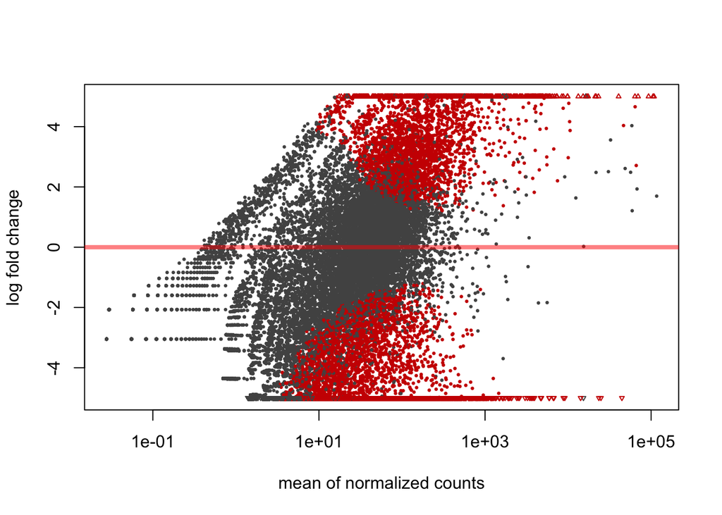

```
## [1] "Most differ expr genes of normalized counts"
```

```
##  [1] "ENSG00000112306" "ENSG00000134419" "ENSG00000137818" "ENSG00000150967"
##  [5] "ENSG00000152348" "ENSG00000156482" "ENSG00000157734" "ENSG00000161970"
##  [9] "ENSG00000164404" "ENSG00000164587" "ENSG00000166710" "ENSG00000167995"
## [13] "ENSG00000186468" "ENSG00000198918" "ENSG00000204954" "ENSG00000206417"
## [17] "ENSG00000233927" "ENSG00000238045" "ENSG00000245970" "ENSG00000251562"
## [21] "ENSG00000258017" "ENSG00000264235" "ENSG00000267598" "ENSG00000279159"
## [25] "ENSG00000280195"
```

Now let’s look at the log10(counts) of the data

```
## [1] "size factors applied for norm were:"
```

```
##    bulk_7319    bulk_7320 sc_mech_7319 sc_mech_7320  sc_enz_7319  sc_enz_7320
##    0.1106848    0.2366106    0.4630043    5.6077567    3.0254173    6.0093794
```

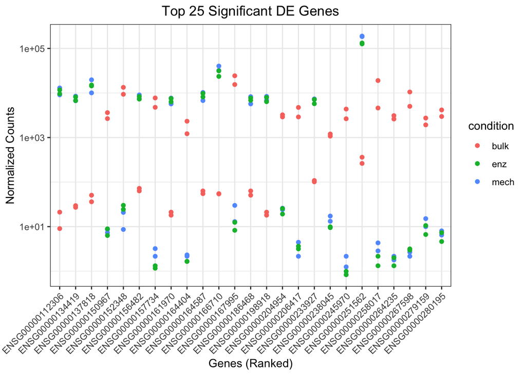

```
## [1] "Heatmap of all normalized counts"
```

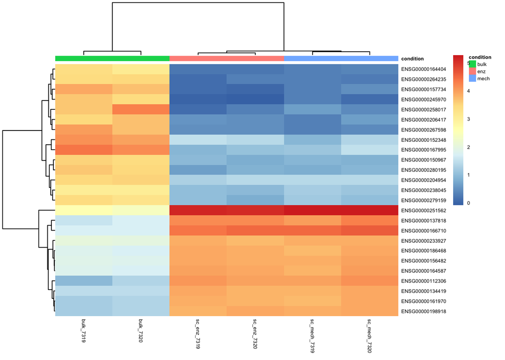